# Risk Factor Analysis

## Outcome Variable

**Outcome Variable:** sstunted

## Predictor Variables

**Intervention Variable:** tr

**Adjustment Set:**

unadjusted

## Stratifying Variables

The analysis was stratified on these variable(s):

- agecat
- studyid
- country

## Data Summary

| agecat | studyid | country | sstunted | n_cell | n |
| --- | --- | --- | --- | --- | --- |
| Birth | iLiNS_DYADM_LNS | MALAWI | 0 | 0 | 1 |
| Birth | iLiNS_DYADM_LNS | MALAWI | 1 | 1 | 1 |
| Birth | ki1000125-AgaKhanUniv | PAKISTAN | 0 | 11 | 11 |
| Birth | ki1000125-AgaKhanUniv | PAKISTAN | 1 | 0 | 11 |
| Birth | ki1000304b-SAS-CompFeed | INDIA | 0 | 133 | 144 |
| Birth | ki1000304b-SAS-CompFeed | INDIA | 1 | 11 | 144 |
| Birth | ki1119695-PROBIT | BELARUS | 0 | 13879 | 13884 |
| Birth | ki1119695-PROBIT | BELARUS | 1 | 5 | 13884 |
| Birth | ki1126311-ZVITAMBO | ZIMBABWE | 0 | 13389 | 13830 |
| Birth | ki1126311-ZVITAMBO | ZIMBABWE | 1 | 441 | 13830 |
| Birth | ki1135781-COHORTS | GUATEMALA | 0 | 841 | 852 |
| Birth | ki1135781-COHORTS | GUATEMALA | 1 | 11 | 852 |
| Birth | ki1148112-iLiNS-DYAD-M | MALAWI | 0 | 0 | 1 |
| Birth | ki1148112-iLiNS-DYAD-M | MALAWI | 1 | 1 | 1 |
| Birth | kiGH5241-JiVitA-3 | BANGLADESH | 0 | 35144 | 39226 |
| Birth | kiGH5241-JiVitA-3 | BANGLADESH | 1 | 4082 | 39226 |
| Birth | kiGH5241-JiVitA-4 | BANGLADESH | 0 | 1516 | 1644 |
| Birth | kiGH5241-JiVitA-4 | BANGLADESH | 1 | 128 | 1644 |
| 6 months | iLiNS_DYADM_LNS | MALAWI | 0 | 650 | 683 |
| 6 months | iLiNS_DYADM_LNS | MALAWI | 1 | 33 | 683 |
| 6 months | ki1000107-Serrinha-VitA | BRAZIL | 0 | 30 | 35 |
| 6 months | ki1000107-Serrinha-VitA | BRAZIL | 1 | 5 | 35 |
| 6 months | ki1000110-WASH-Bangladesh | BANGLADESH | 0 | 654 | 682 |
| 6 months | ki1000110-WASH-Bangladesh | BANGLADESH | 1 | 28 | 682 |
| 6 months | ki1000111-WASH-Kenya | KENYA | 0 | 71 | 74 |
| 6 months | ki1000111-WASH-Kenya | KENYA | 1 | 3 | 74 |
| 6 months | ki1000125-AgaKhanUniv | PAKISTAN | 0 | 614 | 695 |
| 6 months | ki1000125-AgaKhanUniv | PAKISTAN | 1 | 81 | 695 |
| 6 months | ki1000304-EU | INDIA | 0 | 323 | 363 |
| 6 months | ki1000304-EU | INDIA | 1 | 40 | 363 |

[output cut: 72 more lines]

The following strata were considered:

- agecat: 24 months, studyid: iLiNS_DYADM_LNS, country: MALAWI
- agecat: 24 months, studyid: ki1000107-Serrinha-VitA, country: BRAZIL
- agecat: 24 months, studyid: ki1000110-WASH-Bangladesh, country: BANGLADESH
- agecat: 24 months, studyid: ki1000111-WASH-Kenya, country: KENYA
- agecat: 24 months, studyid: ki1000125-AgaKhanUniv, country: PAKISTAN
- agecat: 24 months, studyid: ki1000304-EU, country: INDIA
- agecat: 24 months, studyid: ki1000304-Vitamin-B12, country: INDIA
- agecat: 24 months, studyid: ki1000304-ZnMort, country: INDIA
- agecat: 24 months, studyid: ki1017093b-PROVIDE, country: BANGLADESH
- agecat: 24 months, studyid: ki1066203-TanzaniaChild2, country: TANZANIA, UNITED REPUBLIC OF
- agecat: 24 months, studyid: ki1112895-Burkina Faso Zn, country: BURKINA FASO
- agecat: 24 months, studyid: ki1119695-PROBIT, country: BELARUS
- agecat: 24 months, studyid: ki1126311-ZVITAMBO, country: ZIMBABWE
- agecat: 24 months, studyid: ki1135781-COHORTS, country: GUATEMALA
- agecat: 24 months, studyid: ki1148112-iLiNS-DOSE, country: MALAWI
- agecat: 24 months, studyid: ki1148112-iLiNS-DYAD-M, country: MALAWI
- agecat: 24 months, studyid: ki1148112-LCNI-5, country: MALAWI
- agecat: 24 months, studyid: kiGH5241-JiVitA-3, country: BANGLADESH
- agecat: 24 months, studyid: kiGH5241-JiVitA-4, country: BANGLADESH
- agecat: 6 months, studyid: iLiNS_DYADM_LNS, country: MALAWI
- agecat: 6 months, studyid: ki1000107-Serrinha-VitA, country: BRAZIL
- agecat: 6 months, studyid: ki1000110-WASH-Bangladesh, country: BANGLADESH
- agecat: 6 months, studyid: ki1000111-WASH-Kenya, country: KENYA
- agecat: 6 months, studyid: ki1000125-AgaKhanUniv, country: PAKISTAN
- agecat: 6 months, studyid: ki1000304-EU, country: INDIA
- agecat: 6 months, studyid: ki1000304-VITAMIN-A, country: INDIA
- agecat: 6 months, studyid: ki1000304-Vitamin-B12, country: INDIA
- agecat: 6 months, studyid: ki1000304-ZnMort, country: INDIA
- agecat: 6 months, studyid: ki1000304b-SAS-CompFeed, country: INDIA
- agecat: 6 months, studyid: ki1000304b-SAS-FoodSuppl, country: INDIA
- agecat: 6 months, studyid: ki1017093b-PROVIDE, country: BANGLADESH
- agecat: 6 months, studyid: ki1066203-TanzaniaChild2, country: TANZANIA, UNITED REPUBLIC OF
- agecat: 6 months, studyid: ki1112895-Burkina Faso Zn, country: BURKINA FASO
- agecat: 6 months, studyid: ki1112895-Guatemala BSC, country: GUATEMALA
- agecat: 6 months, studyid: ki1119695-PROBIT, country: BELARUS
- agecat: 6 months, studyid: ki1126311-ZVITAMBO, country: ZIMBABWE
- agecat: 6 months, studyid: ki1135781-COHORTS, country: GUATEMALA
- agecat: 6 months, studyid: ki1148112-iLiNS-DOSE, country: MALAWI
- agecat: 6 months, studyid: ki1148112-iLiNS-DYAD-M, country: MALAWI
- agecat: 6 months, studyid: ki1148112-LCNI-5, country: MALAWI
- agecat: 6 months, studyid: kiGH5241-JiVitA-3, country: BANGLADESH
- agecat: 6 months, studyid: kiGH5241-JiVitA-4, country: BANGLADESH
- agecat: Birth, studyid: iLiNS_DYADM_LNS, country: MALAWI
- agecat: Birth, studyid: ki1000125-AgaKhanUniv, country: PAKISTAN
- agecat: Birth, studyid: ki1000304b-SAS-CompFeed, country: INDIA
- agecat: Birth, studyid: ki1119695-PROBIT, country: BELARUS
- agecat: Birth, studyid: ki1126311-ZVITAMBO, country: ZIMBABWE
- agecat: Birth, studyid: ki1135781-COHORTS, country: GUATEMALA
- agecat: Birth, studyid: ki1148112-iLiNS-DYAD-M, country: MALAWI
- agecat: Birth, studyid: kiGH5241-JiVitA-3, country: BANGLADESH
- agecat: Birth, studyid: kiGH5241-JiVitA-4, country: BANGLADESH

### Dropped Strata

Some strata were dropped due to rare outcomes:

- agecat: Birth, studyid: iLiNS_DYADM_LNS, country: MALAWI
- agecat: Birth, studyid: ki1000125-AgaKhanUniv, country: PAKISTAN
- agecat: Birth, studyid: ki1148112-iLiNS-DYAD-M, country: MALAWI
- agecat: 6 months, studyid: ki1000111-WASH-Kenya, country: KENYA
- agecat: 6 months, studyid: ki1017093b-PROVIDE, country: BANGLADESH
- agecat: 24 months, studyid: iLiNS_DYADM_LNS, country: MALAWI
- agecat: 24 months, studyid: ki1000125-AgaKhanUniv, country: PAKISTAN
- agecat: 24 months, studyid: ki1017093b-PROVIDE, country: BANGLADESH
- agecat: 24 months, studyid: ki1066203-TanzaniaChild2, country: TANZANIA, UNITED REPUBLIC OF

## Methods Detail

We’re interested in the causal parameters $E[Y_a]$ for all values of $a \in \mathcal{A}$. These parameters represent the mean outcome if, possibly contrary to fact, we intervened to set all units to have $A=a$. Under the randomization and positivity assumptions, these are identified by the statistical parameters $\psi_a=E_W[E_{Y|A,W}(Y|A=a,W)]$. In addition, we’re interested in the mean of $Y$, $E[Y]$ under no intervention (the observed mean). We will estimate these parameters by using SuperLearner to fit the relevant likelihood factors – $E_{Y|A,W}(Y|A=a,W)$ and $p(A=a|W)$, and then updating our likelihood fit using a joint TMLE.

For unadjusted analyses ($W=\{\}$), initial likelihoods were estimated using Lrnr_glm to estimate the simple $E(Y|A)$ and Lrnr_mean to estimate $p(A)$. For adjusted analyses, a small library containing Lrnr_glmnet, Lrnr_xgboost, and Lrnr_mean was used.

Having estimated these parameters, we will then use the delta method to estimate relative risks and attributable risks relative to a prespecified baseline level of $A$.

# Results Detail

## Results Plots

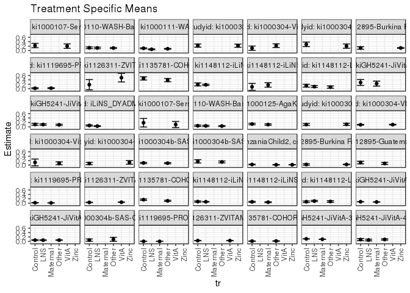

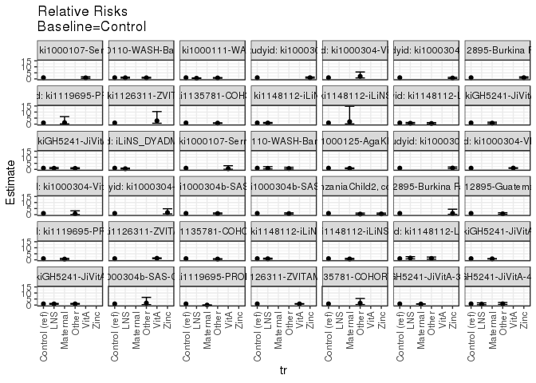

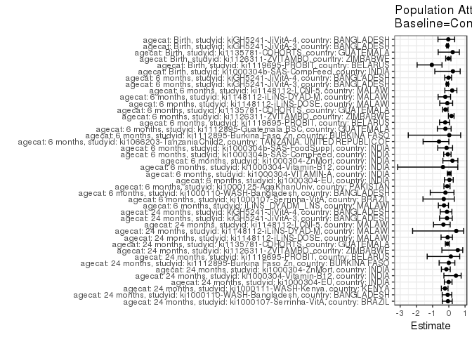

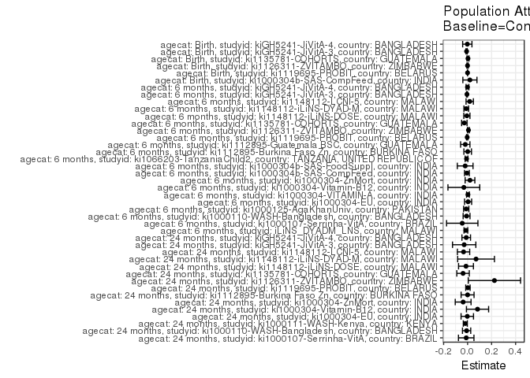

## Results Table

### Parameter: TSM

| agecat | studyid | country | intervention_level | baseline_level | estimate | ci_lower | ci_upper |
| --- | --- | --- | --- | --- | --- | --- | --- |
| Birth | ki1000304b-SAS-CompFeed | INDIA | Control | NA | 0.0571429 | 0.0042326 | 0.1100531 |
| Birth | ki1000304b-SAS-CompFeed | INDIA | Other | NA | 0.0945946 | 0.0034662 | 0.1857230 |
| Birth | ki1119695-PROBIT | BELARUS | Control | NA | 0.0007376 | 0.0002344 | 0.0012407 |
| Birth | ki1119695-PROBIT | BELARUS | Maternal | NA | 0.0000000 | 0.0000000 | 0.0000000 |
| Birth | ki1126311-ZVITAMBO | ZIMBABWE | Control | NA | 0.0324732 | 0.0265574 | 0.0383889 |
| Birth | ki1126311-ZVITAMBO | ZIMBABWE | VitA | NA | 0.0316925 | 0.0283225 | 0.0350625 |
| Birth | ki1135781-COHORTS | GUATEMALA | Control | NA | 0.0098280 | 0.0002386 | 0.0194175 |
| Birth | ki1135781-COHORTS | GUATEMALA | Other | NA | 0.0157303 | 0.0041626 | 0.0272981 |
| Birth | kiGH5241-JiVitA-3 | BANGLADESH | Control | NA | 0.1124564 | 0.1056828 | 0.1192300 |
| Birth | kiGH5241-JiVitA-3 | BANGLADESH | Maternal | NA | 0.0957738 | 0.0894830 | 0.1020646 |
| Birth | kiGH5241-JiVitA-4 | BANGLADESH | Control | NA | 0.0803571 | 0.0331062 | 0.1276081 |
| Birth | kiGH5241-JiVitA-4 | BANGLADESH | LNS | NA | 0.0616740 | 0.0222935 | 0.1010545 |
| Birth | kiGH5241-JiVitA-4 | BANGLADESH | Other | NA | 0.0862534 | 0.0551100 | 0.1173968 |
| 6 months | iLiNS_DYADM_LNS | MALAWI | Control | NA | 0.0626781 | 0.0373025 | 0.0880536 |
| 6 months | iLiNS_DYADM_LNS | MALAWI | LNS | NA | 0.0331325 | 0.0138658 | 0.0523993 |
| 6 months | ki1000107-Serrinha-VitA | BRAZIL | Control | NA | 0.1875000 | -0.0065417 | 0.3815417 |
| 6 months | ki1000107-Serrinha-VitA | BRAZIL | VitA | NA | 0.1052632 | -0.0347445 | 0.2452708 |
| 6 months | ki1000110-WASH-Bangladesh | BANGLADESH | Control | NA | 0.0496894 | 0.0160988 | 0.0832801 |
| 6 months | ki1000110-WASH-Bangladesh | BANGLADESH | LNS | NA | 0.0425532 | 0.0136789 | 0.0714275 |
| 6 months | ki1000110-WASH-Bangladesh | BANGLADESH | Other | NA | 0.0360360 | 0.0160032 | 0.0560689 |
| 6 months | ki1000125-AgaKhanUniv | PAKISTAN | Control | NA | 0.1280000 | 0.0941617 | 0.1618383 |
| 6 months | ki1000125-AgaKhanUniv | PAKISTAN | Maternal | NA | 0.1031250 | 0.0697798 | 0.1364702 |
| 6 months | ki1000304-EU | INDIA | Control | NA | 0.1060606 | 0.0631123 | 0.1490089 |
| 6 months | ki1000304-EU | INDIA | Zinc | NA | 0.1151515 | 0.0663791 | 0.1639239 |
| 6 months | ki1000304-VITAMIN-A | INDIA | Control | NA | 0.0956522 | 0.0794414 | 0.1118630 |
| 6 months | ki1000304-VITAMIN-A | INDIA | VitA | NA | 0.1013677 | 0.0845858 | 0.1181495 |
| 6 months | ki1000304-Vitamin-B12 | INDIA | Control | NA | 0.1176471 | -0.0364637 | 0.2717578 |
| 6 months | ki1000304-Vitamin-B12 | INDIA | Other | NA | 0.0781250 | 0.0119663 | 0.1442837 |
| 6 months | ki1000304-ZnMort | INDIA | Control | NA | 0.0697674 | 0.0157388 | 0.1237961 |
| 6 months | ki1000304-ZnMort | INDIA | Zinc | NA | 0.1186441 | 0.0358454 | 0.2014428 |

[output cut: 63 more lines]

### Parameter: E(Y)

| agecat | studyid | country | intervention_level | baseline_level | estimate | ci_lower | ci_upper |
| --- | --- | --- | --- | --- | --- | --- | --- |
| Birth | ki1000304b-SAS-CompFeed | INDIA | NA | NA | 0.0763889 | 0.0213605 | 0.1314173 |
| Birth | ki1119695-PROBIT | BELARUS | NA | NA | 0.0003601 | 0.0001082 | 0.0006120 |
| Birth | ki1126311-ZVITAMBO | ZIMBABWE | NA | NA | 0.0318872 | 0.0289588 | 0.0348156 |
| Birth | ki1135781-COHORTS | GUATEMALA | NA | NA | 0.0129108 | 0.0053261 | 0.0204955 |
| Birth | kiGH5241-JiVitA-3 | BANGLADESH | NA | NA | 0.1040636 | 0.0993965 | 0.1087307 |
| Birth | kiGH5241-JiVitA-4 | BANGLADESH | NA | NA | 0.0778589 | 0.0559066 | 0.0998111 |
| 6 months | iLiNS_DYADM_LNS | MALAWI | NA | NA | 0.0483163 | 0.0322228 | 0.0644097 |
| 6 months | ki1000107-Serrinha-VitA | BRAZIL | NA | NA | 0.1428571 | 0.0252358 | 0.2604785 |
| 6 months | ki1000110-WASH-Bangladesh | BANGLADESH | NA | NA | 0.0410557 | 0.0261533 | 0.0559582 |
| 6 months | ki1000125-AgaKhanUniv | PAKISTAN | NA | NA | 0.1165468 | 0.0926736 | 0.1404199 |
| 6 months | ki1000304-EU | INDIA | NA | NA | 0.1101928 | 0.0779362 | 0.1424494 |
| 6 months | ki1000304-VITAMIN-A | INDIA | NA | NA | 0.0984849 | 0.0868210 | 0.1101487 |
| 6 months | ki1000304-Vitamin-B12 | INDIA | NA | NA | 0.0864198 | 0.0248478 | 0.1479917 |
| 6 months | ki1000304-ZnMort | INDIA | NA | NA | 0.0896552 | 0.0429938 | 0.1363165 |
| 6 months | ki1000304b-SAS-CompFeed | INDIA | NA | NA | 0.0891410 | 0.0699902 | 0.1082918 |
| 6 months | ki1000304b-SAS-FoodSuppl | INDIA | NA | NA | 0.1464789 | 0.1096455 | 0.1833122 |
| 6 months | ki1066203-TanzaniaChild2 | TANZANIA, UNITED REPUBLIC OF | NA | NA | 0.0146456 | 0.0089451 | 0.0203460 |
| 6 months | ki1112895-Burkina Faso Zn | BURKINA FASO | NA | NA | 0.0253968 | 0.0131019 | 0.0376918 |
| 6 months | ki1112895-Guatemala BSC | GUATEMALA | NA | NA | 0.0917431 | 0.0533362 | 0.1301500 |
| 6 months | ki1119695-PROBIT | BELARUS | NA | NA | 0.0158621 | 0.0104045 | 0.0213196 |
| 6 months | ki1126311-ZVITAMBO | ZIMBABWE | NA | NA | 0.0425669 | 0.0380795 | 0.0470542 |
| 6 months | ki1135781-COHORTS | GUATEMALA | NA | NA | 0.1319742 | 0.1102330 | 0.1537155 |
| 6 months | ki1148112-iLiNS-DOSE | MALAWI | NA | NA | 0.0658031 | 0.0547388 | 0.0768674 |
| 6 months | ki1148112-iLiNS-DYAD-M | MALAWI | NA | NA | 0.0515063 | 0.0379950 | 0.0650177 |
| 6 months | ki1148112-LCNI-5 | MALAWI | NA | NA | 0.0846246 | 0.0657805 | 0.1034686 |
| 6 months | kiGH5241-JiVitA-3 | BANGLADESH | NA | NA | 0.0606576 | 0.0567961 | 0.0645192 |
| 6 months | kiGH5241-JiVitA-4 | BANGLADESH | NA | NA | 0.0562540 | 0.0493164 | 0.0631915 |
| 24 months | ki1000107-Serrinha-VitA | BRAZIL | NA | NA | 0.2137405 | 0.1432707 | 0.2842102 |
| 24 months | ki1000110-WASH-Bangladesh | BANGLADESH | NA | NA | 0.1171019 | 0.0988023 | 0.1354016 |
| 24 months | ki1000111-WASH-Kenya | KENYA | NA | NA | 0.0808304 | 0.0696001 | 0.0920607 |
| 24 months | ki1000304-EU | INDIA | NA | NA | 0.2213439 | 0.1700867 | 0.2726010 |
| 24 months | ki1000304-Vitamin-B12 | INDIA | NA | NA | 0.1879699 | 0.1213213 | 0.2546186 |
| 24 months | ki1000304-ZnMort | INDIA | NA | NA | 0.2428571 | 0.1715710 | 0.3141433 |
| 24 months | ki1112895-Burkina Faso Zn | BURKINA FASO | NA | NA | 0.1154833 | 0.0971543 | 0.1338123 |
| 24 months | ki1119695-PROBIT | BELARUS | NA | NA | 0.0214031 | 0.0054187 | 0.0373875 |
| 24 months | ki1126311-ZVITAMBO | ZIMBABWE | NA | NA | 0.4054054 | 0.2450247 | 0.5657861 |
| 24 months | ki1135781-COHORTS | GUATEMALA | NA | NA | 0.4298507 | 0.3767589 | 0.4829426 |
| 24 months | ki1148112-iLiNS-DOSE | MALAWI | NA | NA | 0.1804124 | 0.1533399 | 0.2074849 |
| 24 months | ki1148112-iLiNS-DYAD-M | MALAWI | NA | NA | 0.1538462 | 0.0654515 | 0.2422408 |
| 24 months | ki1148112-LCNI-5 | MALAWI | NA | NA | 0.1012987 | 0.0711206 | 0.1314768 |
| 24 months | kiGH5241-JiVitA-3 | BANGLADESH | NA | NA | 0.2531646 | 0.1662034 | 0.3401257 |
| 24 months | kiGH5241-JiVitA-4 | BANGLADESH | NA | NA | 0.1002994 | 0.0803286 | 0.1202702 |

### Parameter: RR

| agecat | studyid | country | intervention_level | baseline_level | estimate | ci_lower | ci_upper |
| --- | --- | --- | --- | --- | --- | --- | --- |
| Birth | ki1000304b-SAS-CompFeed | INDIA | Control | Control | 1.0000000 | 1.0000000 | 1.0000000 |
| Birth | ki1000304b-SAS-CompFeed | INDIA | Other | Control | 1.6554054 | 0.4293100 | 6.3831889 |
| Birth | ki1119695-PROBIT | BELARUS | Control | Control | 1.0000000 | 1.0000000 | 1.0000000 |
| Birth | ki1119695-PROBIT | BELARUS | Maternal | Control | 0.0000000 | 0.0000000 | 0.0000001 |
| Birth | ki1126311-ZVITAMBO | ZIMBABWE | Control | Control | 1.0000000 | 1.0000000 | 1.0000000 |
| Birth | ki1126311-ZVITAMBO | ZIMBABWE | VitA | Control | 0.9759597 | 0.7903569 | 1.2051484 |
| Birth | ki1135781-COHORTS | GUATEMALA | Control | Control | 1.0000000 | 1.0000000 | 1.0000000 |
| Birth | ki1135781-COHORTS | GUATEMALA | Other | Control | 1.6005618 | 0.4716784 | 5.4312383 |
| Birth | kiGH5241-JiVitA-3 | BANGLADESH | Control | Control | 1.0000000 | 1.0000000 | 1.0000000 |
| Birth | kiGH5241-JiVitA-3 | BANGLADESH | Maternal | Control | 0.8516527 | 0.7790290 | 0.9310468 |
| Birth | kiGH5241-JiVitA-4 | BANGLADESH | Control | Control | 1.0000000 | 1.0000000 | 1.0000000 |
| Birth | kiGH5241-JiVitA-4 | BANGLADESH | LNS | Control | 0.7674988 | 0.3221119 | 1.8287259 |
| Birth | kiGH5241-JiVitA-4 | BANGLADESH | Other | Control | 1.0733753 | 0.5383956 | 2.1399402 |
| 6 months | iLiNS_DYADM_LNS | MALAWI | Control | Control | 1.0000000 | 1.0000000 | 1.0000000 |
| 6 months | iLiNS_DYADM_LNS | MALAWI | LNS | Control | 0.5286145 | 0.2602651 | 1.0736486 |
| 6 months | ki1000107-Serrinha-VitA | BRAZIL | Control | Control | 1.0000000 | 1.0000000 | 1.0000000 |
| 6 months | ki1000107-Serrinha-VitA | BRAZIL | VitA | Control | 0.5614035 | 0.1040825 | 3.0281160 |
| 6 months | ki1000110-WASH-Bangladesh | BANGLADESH | Control | Control | 1.0000000 | 1.0000000 | 1.0000000 |
| 6 months | ki1000110-WASH-Bangladesh | BANGLADESH | LNS | Control | 0.8563830 | 0.3286190 | 2.2317389 |
| 6 months | ki1000110-WASH-Bangladesh | BANGLADESH | Other | Control | 0.7252252 | 0.3022487 | 1.7401287 |
| 6 months | ki1000125-AgaKhanUniv | PAKISTAN | Control | Control | 1.0000000 | 1.0000000 | 1.0000000 |
| 6 months | ki1000125-AgaKhanUniv | PAKISTAN | Maternal | Control | 0.8056641 | 0.5305986 | 1.2233251 |
| 6 months | ki1000304-EU | INDIA | Control | Control | 1.0000000 | 1.0000000 | 1.0000000 |
| 6 months | ki1000304-EU | INDIA | Zinc | Control | 1.0857143 | 0.6042658 | 1.9507567 |
| 6 months | ki1000304-VITAMIN-A | INDIA | Control | Control | 1.0000000 | 1.0000000 | 1.0000000 |
| 6 months | ki1000304-VITAMIN-A | INDIA | VitA | Control | 1.0597528 | 0.8362036 | 1.3430652 |
| 6 months | ki1000304-Vitamin-B12 | INDIA | Control | Control | 1.0000000 | 1.0000000 | 1.0000000 |
| 6 months | ki1000304-Vitamin-B12 | INDIA | Other | Control | 0.6640625 | 0.1395673 | 3.1596160 |
| 6 months | ki1000304-ZnMort | INDIA | Control | Control | 1.0000000 | 1.0000000 | 1.0000000 |
| 6 months | ki1000304-ZnMort | INDIA | Zinc | Control | 1.7005650 | 0.5995909 | 4.8231576 |

[output cut: 63 more lines]

### Parameter: PAR

| agecat | studyid | country | intervention_level | baseline_level | estimate | ci_lower | ci_upper |
| --- | --- | --- | --- | --- | --- | --- | --- |
| Birth | ki1000304b-SAS-CompFeed | INDIA | Control | NA | 0.0192460 | -0.0395652 | 0.0780572 |
| Birth | ki1119695-PROBIT | BELARUS | Control | NA | -0.0003774 | -0.0006916 | -0.0000633 |
| Birth | ki1126311-ZVITAMBO | ZIMBABWE | Control | NA | -0.0005860 | -0.0056964 | 0.0045244 |
| Birth | ki1135781-COHORTS | GUATEMALA | Control | NA | 0.0030828 | -0.0047676 | 0.0109332 |
| Birth | kiGH5241-JiVitA-3 | BANGLADESH | Control | NA | -0.0083928 | -0.0131065 | -0.0036790 |
| Birth | kiGH5241-JiVitA-4 | BANGLADESH | Control | NA | -0.0024983 | -0.0411951 | 0.0361986 |
| 6 months | iLiNS_DYADM_LNS | MALAWI | Control | NA | -0.0143618 | -0.0298888 | 0.0011651 |
| 6 months | ki1000107-Serrinha-VitA | BRAZIL | Control | NA | -0.0446429 | -0.1752649 | 0.0859792 |
| 6 months | ki1000110-WASH-Bangladesh | BANGLADESH | Control | NA | -0.0086337 | -0.0372289 | 0.0199615 |
| 6 months | ki1000125-AgaKhanUniv | PAKISTAN | Control | NA | -0.0114532 | -0.0333465 | 0.0104400 |
| 6 months | ki1000304-EU | INDIA | Control | NA | 0.0041322 | -0.0254110 | 0.0336754 |
| 6 months | ki1000304-VITAMIN-A | INDIA | Control | NA | 0.0028327 | -0.0087319 | 0.0143973 |
| 6 months | ki1000304-Vitamin-B12 | INDIA | Control | NA | -0.0312273 | -0.1637869 | 0.1013323 |
| 6 months | ki1000304-ZnMort | INDIA | Control | NA | 0.0198877 | -0.0205317 | 0.0603071 |
| 6 months | ki1000304b-SAS-CompFeed | INDIA | Control | NA | -0.0057742 | -0.0256356 | 0.0140871 |
| 6 months | ki1000304b-SAS-FoodSuppl | INDIA | Control | NA | -0.0201878 | -0.0856652 | 0.0452896 |
| 6 months | ki1066203-TanzaniaChild2 | TANZANIA, UNITED REPUBLIC OF | Control | NA | -0.0088838 | -0.0205807 | 0.0028131 |
| 6 months | ki1112895-Burkina Faso Zn | BURKINA FASO | Control | NA | 0.0007055 | -0.0309319 | 0.0323428 |
| 6 months | ki1112895-Guatemala BSC | GUATEMALA | Control | NA | -0.0193680 | -0.0581941 | 0.0194581 |
| 6 months | ki1119695-PROBIT | BELARUS | Control | NA | -0.0035418 | -0.0088564 | 0.0017729 |
| 6 months | ki1126311-ZVITAMBO | ZIMBABWE | Control | NA | 0.0070763 | -0.0003366 | 0.0144891 |
| 6 months | ki1135781-COHORTS | GUATEMALA | Control | NA | -0.0273178 | -0.0498325 | -0.0048031 |
| 6 months | ki1148112-iLiNS-DOSE | MALAWI | Control | NA | -0.0060719 | -0.0317225 | 0.0195787 |
| 6 months | ki1148112-iLiNS-DYAD-M | MALAWI | Control | NA | -0.0111717 | -0.0308462 | 0.0085027 |
| 6 months | ki1148112-LCNI-5 | MALAWI | Control | NA | 0.0176389 | -0.0128932 | 0.0481710 |
| 6 months | kiGH5241-JiVitA-3 | BANGLADESH | Control | NA | -0.0053334 | -0.0092361 | -0.0014307 |
| 6 months | kiGH5241-JiVitA-4 | BANGLADESH | Control | NA | -0.0011466 | -0.0129338 | 0.0106406 |
| 24 months | ki1000107-Serrinha-VitA | BRAZIL | Control | NA | -0.0116117 | -0.0761623 | 0.0529390 |
| 24 months | ki1000110-WASH-Bangladesh | BANGLADESH | Control | NA | -0.0083593 | -0.0427210 | 0.0260023 |
| 24 months | ki1000111-WASH-Kenya | KENYA | Control | NA | -0.0191696 | -0.0357732 | -0.0025660 |
| 24 months | ki1000304-EU | INDIA | Control | NA | -0.0026561 | -0.0545299 | 0.0492177 |
| 24 months | ki1000304-Vitamin-B12 | INDIA | Control | NA | 0.0827068 | -0.0097778 | 0.1751914 |
| 24 months | ki1000304-ZnMort | INDIA | Control | NA | -0.0371429 | -0.1030128 | 0.0287271 |
| 24 months | ki1112895-Burkina Faso Zn | BURKINA FASO | Control | NA | -0.0002192 | -0.0542005 | 0.0537622 |
| 24 months | ki1119695-PROBIT | BELARUS | Control | NA | 0.0026865 | -0.0155185 | 0.0208915 |
| 24 months | ki1126311-ZVITAMBO | ZIMBABWE | Control | NA | 0.2235872 | 0.0059452 | 0.4412293 |
| 24 months | ki1135781-COHORTS | GUATEMALA | Control | NA | -0.0379855 | -0.0899617 | 0.0139907 |
| 24 months | ki1148112-iLiNS-DOSE | MALAWI | Control | NA | -0.0133861 | -0.0753755 | 0.0486034 |
| 24 months | ki1148112-iLiNS-DYAD-M | MALAWI | Control | NA | 0.0705128 | -0.0827167 | 0.2237424 |
| 24 months | ki1148112-LCNI-5 | MALAWI | Control | NA | -0.0338364 | -0.0850968 | 0.0174239 |
| 24 months | kiGH5241-JiVitA-3 | BANGLADESH | Control | NA | -0.0285256 | -0.1257808 | 0.0687297 |
| 24 months | kiGH5241-JiVitA-4 | BANGLADESH | Control | NA | -0.0114540 | -0.0472648 | 0.0243569 |

### Parameter: PAF

| agecat | studyid | country | intervention_level | baseline_level | estimate | ci_lower | ci_upper |
| --- | --- | --- | --- | --- | --- | --- | --- |
| Birth | ki1000304b-SAS-CompFeed | INDIA | Control | NA | 0.2519481 | -0.8640133 | 0.6997974 |
| Birth | ki1119695-PROBIT | BELARUS | Control | NA | -1.0480896 | -1.9539988 | -0.4199976 |
| Birth | ki1126311-ZVITAMBO | ZIMBABWE | Control | NA | -0.0183766 | -0.1919318 | 0.1299075 |
| Birth | ki1135781-COHORTS | GUATEMALA | Control | NA | 0.2387760 | -0.6567218 | 0.6502358 |
| Birth | kiGH5241-JiVitA-3 | BANGLADESH | Control | NA | -0.0806503 | -0.1268989 | -0.0362997 |
| Birth | kiGH5241-JiVitA-4 | BANGLADESH | Control | NA | -0.0320871 | -0.6684832 | 0.3615736 |
| 6 months | iLiNS_DYADM_LNS | MALAWI | Control | NA | -0.2972460 | -0.6446720 | -0.0232114 |
| 6 months | ki1000107-Serrinha-VitA | BRAZIL | Control | NA | -0.3125000 | -1.5932009 | 0.3357027 |
| 6 months | ki1000110-WASH-Bangladesh | BANGLADESH | Control | NA | -0.2102928 | -1.1452027 | 0.3171700 |
| 6 months | ki1000125-AgaKhanUniv | PAKISTAN | Control | NA | -0.0982716 | -0.3022322 | 0.0737439 |
| 6 months | ki1000304-EU | INDIA | Control | NA | 0.0375000 | -0.2714413 | 0.2713731 |
| 6 months | ki1000304-VITAMIN-A | INDIA | Control | NA | 0.0287625 | -0.0960123 | 0.1393325 |
| 6 months | ki1000304-Vitamin-B12 | INDIA | Control | NA | -0.3613445 | -3.1511438 | 0.5535546 |
| 6 months | ki1000304-ZnMort | INDIA | Control | NA | 0.2218247 | -0.3664654 | 0.5568444 |
| 6 months | ki1000304b-SAS-CompFeed | INDIA | Control | NA | -0.0647766 | -0.3144324 | 0.1374610 |
| 6 months | ki1000304b-SAS-FoodSuppl | INDIA | Control | NA | -0.1378205 | -0.6841463 | 0.2312809 |
| 6 months | ki1066203-TanzaniaChild2 | TANZANIA, UNITED REPUBLIC OF | Control | NA | -0.6065882 | -1.5859636 | 0.0018708 |
| 6 months | ki1112895-Burkina Faso Zn | BURKINA FASO | Control | NA | 0.0277778 | -2.5010736 | 0.7300211 |
| 6 months | ki1112895-Guatemala BSC | GUATEMALA | Control | NA | -0.2111111 | -0.7077384 | 0.1410920 |
| 6 months | ki1119695-PROBIT | BELARUS | Control | NA | -0.2232846 | -0.5724474 | 0.0483464 |
| 6 months | ki1126311-ZVITAMBO | ZIMBABWE | Control | NA | 0.1662388 | -0.0264213 | 0.3227365 |
| 6 months | ki1135781-COHORTS | GUATEMALA | Control | NA | -0.2069933 | -0.3877392 | -0.0497887 |
| 6 months | ki1148112-iLiNS-DOSE | MALAWI | Control | NA | -0.0922736 | -0.5603346 | 0.2353809 |
| 6 months | ki1148112-iLiNS-DYAD-M | MALAWI | Control | NA | -0.2169005 | -0.6605794 | 0.1082349 |
| 6 months | ki1148112-LCNI-5 | MALAWI | Control | NA | 0.2084372 | -0.2446109 | 0.4965723 |
| 6 months | kiGH5241-JiVitA-3 | BANGLADESH | Control | NA | -0.0879267 | -0.1540488 | -0.0255931 |
| 6 months | kiGH5241-JiVitA-4 | BANGLADESH | Control | NA | -0.0203822 | -0.2529726 | 0.1690323 |
| 24 months | ki1000107-Serrinha-VitA | BRAZIL | Control | NA | -0.0543260 | -0.4037261 | 0.2081053 |
| 24 months | ki1000110-WASH-Bangladesh | BANGLADESH | Control | NA | -0.0713850 | -0.4087361 | 0.1851805 |
| 24 months | ki1000111-WASH-Kenya | KENYA | Control | NA | -0.2371585 | -0.4581567 | -0.0496547 |
| 24 months | ki1000304-EU | INDIA | Control | NA | -0.0120000 | -0.2757076 | 0.1971954 |
| 24 months | ki1000304-Vitamin-B12 | INDIA | Control | NA | 0.4400000 | -0.3039978 | 0.7595088 |
| 24 months | ki1000304-ZnMort | INDIA | Control | NA | -0.1529412 | -0.4575040 | 0.0879796 |
| 24 months | ki1112895-Burkina Faso Zn | BURKINA FASO | Control | NA | -0.0018978 | -0.5975147 | 0.3716495 |
| 24 months | ki1119695-PROBIT | BELARUS | Control | NA | 0.1255199 | -1.3343648 | 0.6724096 |
| 24 months | ki1126311-ZVITAMBO | ZIMBABWE | Control | NA | 0.5515152 | -0.4277720 | 0.8591241 |
| 24 months | ki1135781-COHORTS | GUATEMALA | Control | NA | -0.0883691 | -0.2166112 | 0.0263552 |
| 24 months | ki1148112-iLiNS-DOSE | MALAWI | Control | NA | -0.0741971 | -0.4789768 | 0.2197988 |
| 24 months | ki1148112-iLiNS-DYAD-M | MALAWI | Control | NA | 0.4583333 | -2.2326165 | 0.9092368 |
| 24 months | ki1148112-LCNI-5 | MALAWI | Control | NA | -0.3340263 | -0.9393723 | 0.0823700 |
| 24 months | kiGH5241-JiVitA-3 | BANGLADESH | Control | NA | -0.1126761 | -0.5713145 | 0.2120941 |
| 24 months | kiGH5241-JiVitA-4 | BANGLADESH | Control | NA | -0.1141978 | -0.5328055 | 0.1900886 |